# Baseline Mccall (1970) Job search model - first draft

--- title: Mccall (1970) Job Search Model Simulation [Python] categories: Bayesian ---

```python
from scipy.stats import norm
import scipy.integrate as integrate
import numpy as np
import matplotlib.pyplot as plt
%matplotlib inline
# By Sheng BI
```

### The McCall Model

Consider an unemployed worker, infinitely lived. At each time $t$, she receives a job offer $w_{t}$.

The job offer is drawn from an $i.i.d.$ distribution with respect to $t$. Let $F(w_{t})$ denote the probability that wage $w_{t}$ is offered.

Upon receiving $w_{t}$, her decision is :

- Accept $w_{t}$, and work permanently at this wage
- Reject $w_{t}$, eat the unemployment benefit $b$, wait until the next wage offer comes

Thus she is in either one of the two states: employed or unemployed

An unemployed maximizes her lifetime expected utility - the discounted sum of consumption $c_{t}$. In this simplified model, our worker can not save to transfer assets intertemporally, so her consumption is equal to her income $c_{t} = y_{t}$ .

$$ \begin{eqnarray*} \Sigma_{t=0}^{\infty} E[\beta\times y_{t}] \tag{1} \end{eqnarray*} $$

where

$$y_{t}=\begin{cases} w & \text{if accept}\\ b & \text{if reject} \end{cases} $$

Parameters:

- $w_{t}$ the wage, for $t = 1, 2, 3, ...$
- $\beta \in (0,1)$ the discount factor
  - The greater the value, the more patient is the worker, or she is more willing to wait until a better offer comes.
- $y_{t}$ the income
  - $Y_{t} = w_{t}$ when employed
  - $Y_{t} = b$ when unemployment

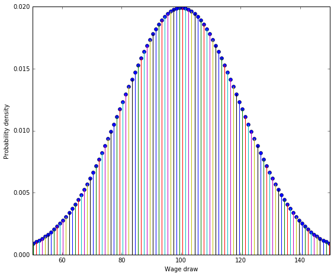

```python
## Sampling wages from normal distribution.

w_min, w_max = 0, 200
w_vals = np.linspace(w_min, w_max, (w_max-w_min))

w_mean, w_std = 100, 20
wpdf_vals = norm.pdf(w_vals, loc = w_mean, scale = w_std)


my_benefit = 30
my_beta = 0.99

class MccallModel():
    def __init__(self, b = my_benefit,\
                beta = my_beta,\
                wage_vals = w_vals,\
                wpdf_vals = wpdf_vals):
        '''
        Publicly accessible and modifiable class attributes.
        '''
        self.compensation = b
        self.beta = beta
        self.wVals = wage_vals
        self.wpdfVals = wpdf_vals

        return

fig, ax = plt.subplots(figsize=(9, 7.5))
ax.stem(w_vals, wpdf_vals, linefmt = '')
# ax.set_xlim(w_min,w_max)
ax.set_xlim(50,150)
ax.set_xlabel('Wage draw')
ax.set_ylabel('Probability density')

plt.show()

# ref: https://stackoverflow.com/questions/7406943/python-immutable-private-class-variables
```

We are interested in the case where the worker makes optimal decisions.

By convention, let $\sigma$ be the worker's decision on whether or not to accept the wage offer $w$.An optimal policy is a function from state to decision.

$$\sigma(w)=\begin{cases} \frac{w}{1-\beta} & \text{if accept}\\ b + \beta \int_{0}^{B}V_{\sigma}(w')dF(w') & \text{if reject} \end{cases} $$

Here, $V_{\sigma}(w)$ denotes the expected lifetime utility value of a worker who enters into the current period unemployed and receives a wage offer $w$.

More importantly, let $V_{\sigma}(w)$ be the value when the worker makes optimal decisions *at the current period and at all future time points*.

Bellman's equation for the unemployed:

\begin{eqnarray*} V_{\sigma}(w) = max(\frac{w}{1-\beta}, b + \beta E[V_{\sigma}(w')]) \end{eqnarray*}

or

\begin{eqnarray*} V_{\sigma}(w) = max(\frac{w}{1-\beta}, b + \beta \int_{0}^{B}V_{\sigma}(w')dF(w')) \end{eqnarray*}

where $B$ is the upperbound for $w_{t}$

### Economic Trade Off in Mccall's model

Worker's tradeoff: accept the job offer early, or wait until a better offer to come in the future.

- Waiting too long for a good offer is costly, since the future is discounted
- Accepting too early is costly, since better offers might arrive in the future

Existence of optimal policies follows from Contraction Mapping Theorem.

Optimal policy: accept when $w = \bar{w}$

- wage offers above $\bar{w}$ will be accepted, otherwise turned down.
- this is a reservation wage strategy.

Reservation wage is given by

$$ \begin{eqnarray*} \frac{\bar{w}}{1-\beta} = \bar{V_\sigma} = b + \beta \int_{0}^{B}V_\sigma(w')dF(w') \end{eqnarray*} $$

So that $\bar{V_\sigma}$ must be a function of $\bar{w}$, which is determined by other parameters in the model.

for all $w < \bar{w}$,

$$ \begin{eqnarray} V_\sigma(w) & = & b + \beta \int_{0}^{B}V_\sigma(w')dF(w') \\ & = & \frac{\bar{w}}{1-\beta} \end{eqnarray} $$

for all $w > \bar{w}$,

$$ \begin{eqnarray} V_\sigma(w) = \frac{w}{1-\beta} \end{eqnarray} $$

So that we obtain:

\begin{eqnarray*} \frac{\bar{w}}{1-\beta} = b + \beta \int_{0}^{\bar{w}}\frac{\bar{w}}{1-\beta}dF(w') + \beta \int_{\bar{w}}^{B}\frac{w'}{1-\beta}dF(w') \tag{2} \end{eqnarray*}

Since

\begin{eqnarray*} 1 = \int_{0}^{B}dF(w') = \int_{0}^{\bar{w}}dF(w') + \int_{\bar{w}}^{B}dF(w') \end{eqnarray*}

we can rearrange $(2)$ to obtain

\begin{eqnarray*} \bar{w}\int_{0}^{\bar{w}}dF(w') - b = \frac{1}{1-\beta} \int_{\bar{w}}^{B}(\beta w' - \bar{w})dF(w') \tag{3} \end{eqnarray*}

Adding both sides of the following equation to $(3)$

\begin{eqnarray*} \bar{w}\int_{\bar{w}}^{B}dF(w') = \frac{(1-\beta)\bar{w}}{1-\beta} \int_{\bar{w}}^{B}dF(w') \end{eqnarray*}

we rearrange, we obtain:

\begin{eqnarray*} \bar{w} - b = \frac{\beta}{1-\beta} \int_{\bar{w}}^{B}(w' - \bar{w})dF(w') \tag{4} \end{eqnarray*}

- Now the left hand side $\bar{w} - b$ is the cost of turning down a wage off $\bar{w}$ to continue searching
- The right hand side $\frac{\beta}{1-\beta} \int_{\bar{w}}^{B}(w' - \bar{w})dF(w')$ represents the expected discounted benefit of turning dow a wage offer $\bar{w}$ to continue searching.

**The following code confirms that there exists a solution for $\bar{w}$. And this reservation wage is greater than the discounted sum of unemployment benefit. This is because anticipation of future employment possibility brings utility.**

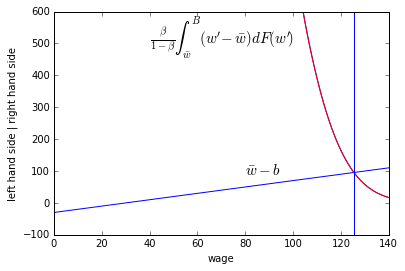

```python
## https://matplotlib.org/users/pyplot_tutorial.html

def lhs(rvw, slope = 1, intercept = - my_benefit):
    return slope * rvw + intercept

def integrand_continuous(x, rvw):
    result = (x-rvw) * norm.pdf(x, loc = w_mean, scale = w_std)
    return result

def integrand_discrete(rvw, x, std = w_std):
    result = np.where(x>=rvw, (x-rvw) * norm.pdf(x, loc = w_mean, scale = std), 0)
    # result = np.where(x>=rvw, (x-rvw) * F_vals,0)
    return result

def rhs(rvw, beta = my_beta, B= 2000, continuous = True, std = w_std):
    '''
    In python, integration can not be vectorized.
    '''
    result = []
    if continuous:
        for w in rvw:
            result.append(integrate.quad(integrand_continuous, \
                                         w, B, args = (w))[0])
        result = (beta/(1-beta)) * np.array(result)
    if not continuous:
        result = map(lambda w: (my_beta/(1-my_beta)) * \
                     np.sum(integrand_discrete(w, x = w_vals, std = std)), steps)
        # result = [np.sum(integrand(w,x=w_vals)) for w in steps]
        # for each in steps:
        #     result.append(np.sum(integrand(w_vals, each)))
    return result

steps = np.arange(0.0, 170.0, 1)

fig, ax = plt.subplots()

ax.plot(steps, lhs(steps), 'b-')
ax.plot(steps, rhs(steps, continuous = True), 'b-')
ax.plot(steps, rhs(steps, continuous = False), 'r-') ## discrete approximation
ax.set_ylim(-100,600)
ax.set_xlim(0,140)
# plt.show()
ax.text(80, 90, r'$\bar{w} - b$', fontsize = 15)
ax.text(40, 500, \
        r"$\frac{\beta}{1-\beta} \int_{\bar{w}}^{B}(w' - \bar{w})dF(w')$", \
        fontsize = 15)

ax.axvline(x=125.4, ymin = 0, ymax = 600)
ax.set_xlabel("wage")
ax.set_ylabel("left hand side | right hand side")
```

We also notice that discrete sum is a good approximation for the integration, which proceeds slowly.

Now, how does the solution vary with respect to standard deviation of wage distribution?

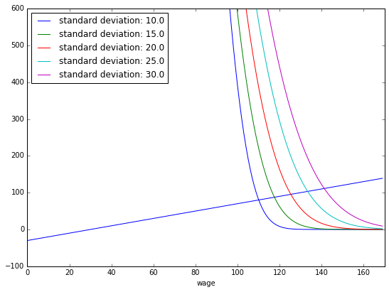

```python
steps = np.arange(0.0, 170.0, 1)

fig, ax = plt.subplots(figsize=(9, 6.5))

ax.plot(steps, lhs(steps), 'b-')
for each in np.linspace(10,30,5):
    ax.plot(steps, rhs(steps, continuous = False, std = each),
           label = "standard deviation: {}".format(each)) ## discrete approximation

ax.set_ylim(-100,600)
ax.set_xlim(0,170)
# plt.show()
ax.legend(loc = 'upper left')
ax.set_xlabel("wage")
```

Comparative Statics:

In the following, we use iteration to solve the model as in the original lecture.As $t$ increases, the contraction mapping theorem leads the worker's strategy to converge her reservation strategy, at which point the value of our value function $V$ is optimal.

\begin{eqnarray*} V_{\sigma, t+1}(w) = max(\frac{w}{1-\beta}, b + \beta \int_{0}^{B}V_{\sigma, t}(w')dF(w')) \end{eqnarray*}

```
9880.495057814362
10609.039405556166
11002.654075744707
11257.101968395358
11435.813148475774
11567.890726454656
11668.481467944921
11746.836580716454
11808.857339215134
11858.620490352594
```

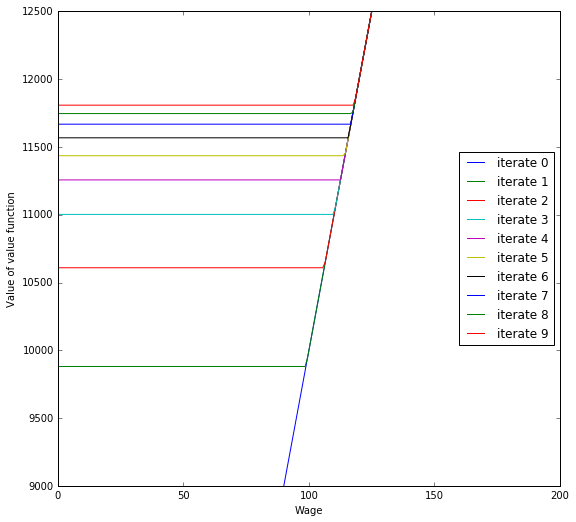

```python
class ValueFunction(MccallModel):
    """
    Inheritance
    """
    def __init__(self, b = my_benefit,\
                 beta = my_beta,\
                 wage_vals = w_vals,\
                 wpdf_vals = wpdf_vals):
        MccallModel.__init__(self)

        # initialization of v

        self.current = self.wVals / (1 - self.beta)
        self.next = np.empty_like(self.current)
        return


valueFunc = ValueFunction()

fig, ax = plt.subplots(figsize=(9, 8.5))

for i in range(10):
    ax.plot(w_vals, valueFunc.current,\
            label="iterate {}".format(i))

    valueFunc.next = \
    map(lambda val: \
        np.maximum(val, my_benefit + \
                   my_beta * np.sum(np.multiply(valueFunc.current,valueFunc.wpdfVals))), \
        w_vals/(1-my_beta))

    valueFunc.current[:] = valueFunc.next

    print(valueFunc.next[30])

ax.set_ylim(9000,12500)
ax.set_xlim(0,200)
ax.set_xlabel("Wage")
ax.set_ylabel("Value of value function")
ax.legend(loc='center right')
```

```python
def solve_model(b = my_benefit, beta = my_beta,\
                wage_vals = w_vals,\
                wpdf_vals = wpdf_vals,\
                num_iter=1000,tol=1e-8):

    valueFunc = ValueFunction()

    i, bias = 0, 100

    while (i < num_iter and bias > tol):

        valueFunc.next = \
        map(lambda val: \
            np.maximum(val, my_benefit + my_beta * np.sum(valueFunc.current * wpdf_vals)), \
            w_vals/(1-my_beta))

        ref = np.copy(valueFunc.current)

        valueFunc.current[:] = valueFunc.next

        bias = np.max(np.abs(valueFunc.current - ref))

        i += 1

    reservation_wage = (1 - beta) * \
    (b + beta * np.sum(valueFunc.current * valueFunc.wpdfVals))

    return valueFunc, reservation_wage


print(solve_model()[1])
```

```
120.88858591653833
```

The gap between the reservation wage solved from iteration and the reservation wage solved using equation $(4)$ is because normal distribution is continuous, and we were using discrete approximation of the probability density to compute the value function.

### References:

1. https://lectures.quantecon.org/py/mccall_model.html
2. Mit Lecture on Labor Economics: https://economics.mit.edu/files/10284

#### Variations of the model.

- purchasing power, anticipation of inflation